# **Présentation** : Mission et Démarche

## 11) - Feature Selection avec **SelectPercentile**

Pour chaque dataset correspondant à un de nos estimateurs npous allons pratiquer le test **f_regression**, qui donnera un *score de linéarité* de chaque variable avec la cible.  
A partir de là, grâce à **SelectPercentile**, nous verrons si on améliore nos modèles en nous passant éventuellement des "**x%** *moins bonnes variables*".

### **Ridge**

```python
f_regression(X_ridge_rfe, y)
```

```
(array([2.65517529e+02, 1.10992885e+02, 5.79381180e+02, 5.65966636e+03,
        2.61984600e+02, 2.93728877e+01, 1.27410627e+02, 5.42943280e+01,
        1.01249224e+02, 3.65765900e-01, 1.60867233e+02, 5.41474587e+02,
        1.01211956e-01, 6.36583928e+01, 1.76542640e+02, 5.65773479e+00,
        1.14273764e+02, 1.02850842e+02, 8.47065484e+01, 2.82476567e+00,
        4.07312463e+01, 4.78387830e+02, 5.66815857e+02, 3.71573255e+01,
        4.70928066e-01, 1.33008472e+01, 2.22263333e-01, 5.43782528e+01,
        5.22665405e-02, 2.30427813e-01, 4.09256756e+00, 1.30069268e+00,
        3.20944085e+01, 3.77961378e+01, 2.72250885e+00, 6.49260585e+01,
        1.61081497e+01, 5.53883618e+01, 3.80158069e+01, 6.57938742e-01,
        1.61081497e+01, 2.31144204e+01, 1.01000425e+01, 3.38099248e-01,
        2.42157497e+00, 1.02850842e+02, 8.64093467e+01, 2.82476567e+00,
        4.83191749e+01, 8.80873583e-02, 6.97371954e+00, 6.84502174e-01,
        3.78477997e+01, 3.14443453e+02, 1.46494243e+00, 9.53524316e-01,
        5.42597104e+01, 1.35262772e+02, 2.19937003e+01, 2.30076950e-01,
        7.24384367e+00, 2.36134296e-01, 4.03885730e+00, 1.64847673e-01,
        7.96313043e+00, 1.64618651e+00, 5.03043364e-01, 1.25714591e-01,
        4.06200191e+00, 3.61714276e+01, 1.15218467e-04, 5.22665405e-02,
        1.61418118e+00, 4.15428653e-02, 6.20418600e+00, 1.30527399e+00,
        3.26346944e+01, 3.89842579e+01, 5.36417594e-02, 4.04237575e+00,
        5.64704455e+01, 9.73715227e+00, 3.80158069e+01, 1.11410285e+00,
        2.83268077e+01, 1.07377637e-01, 8.40016729e-01, 1.30255880e+00,
        8.01084560e-01, 3.23292569e-02, 6.45359341e+00, 1.45744620e+00,
        5.56462937e-02, 2.49920683e+01, 4.98697356e-01, 1.45478961e+00,
        1.79862752e+00, 9.17691797e+00, 1.61134375e+02, 1.59044223e+00,
        1.48184697e+00, 4.90675830e-02, 2.52775417e+00, 1.29697001e-02,
        1.20044448e+00, 1.00095204e+00, 1.03926768e-01, 3.56655781e+00,
        2.65317489e+00, 4.30755476e-03, 7.45824513e+01, 2.20083169e+00,
        2.15139534e+00, 9.69316912e-02, 2.68044131e+00, 1.93571372e+00,
        1.55169677e-01, 1.31634477e+00, 6.99196927e+00, 1.62768328e+00,
        2.77085984e-02, 2.34760432e+00, 2.13623121e+02, 6.87050070e+01,
        2.52709536e-01, 2.84213732e+00, 6.79592858e+01, 1.14108225e+01,
        2.22928693e+01, 1.10801639e+01, 1.94540665e+01, 8.18550276e+00,
        5.44972389e-02, 7.00783898e-01, 1.81164910e-04, 4.87700341e+00,
        1.99007636e+01, 6.46497055e+00, 8.61857259e+00, 2.53358212e+00,
        1.02859005e+02, 3.53551653e+01, 2.25759739e+02, 4.22197202e+02]),
 array([1.77892417e-057, 1.50368150e-025, 4.38582639e-118, 0.00000000e+000,
        9.18826436e-057, 6.39932834e-008, 5.10391614e-029, 2.17000945e-013,
        1.76212380e-023, 5.45362879e-001, 4.99985752e-036, 4.91223252e-111,
        7.50400183e-001, 2.02260856e-015, 2.76444240e-039, 1.74351202e-002,
```

[output cut: 17 more lines]

```
        1.09309118e-007, 7.43170422e-001, 3.59458938e-001, 2.53829144e-001,
        3.70834558e-001, 8.57317963e-001, 1.11182604e-002, 2.27423391e-001,
        8.13529041e-001, 6.05654227e-007, 4.80122889e-001, 2.27847411e-001,
        1.79970777e-001, 2.46984674e-003, 4.39852483e-036, 2.07352082e-001,
        2.23572786e-001, 8.24707466e-001, 1.11955082e-001, 9.09336206e-001,
        2.73312789e-001, 3.17153583e-001, 7.47187712e-001, 5.90420009e-002,
        1.03438731e-001, 9.47674814e-001, 8.90592072e-018, 1.38031766e-001,
        1.42535643e-001, 7.55562926e-001, 1.01682890e-001, 1.64228445e-001,
        6.93668630e-001, 2.51332251e-001, 8.22637871e-003, 2.02113548e-001,
        8.67805942e-001, 1.25571532e-001, 6.31295524e-047, 1.64368309e-016,
        6.15207174e-001, 9.19165095e-002, 2.38079673e-016, 7.38635607e-004,
        2.43816882e-006, 8.82132558e-004, 1.06339007e-005, 4.24919811e-003,
        8.15429233e-001, 4.02581018e-001, 9.89261810e-001, 2.72853130e-002,
        8.42896795e-006, 1.10474414e-002, 3.35050421e-003, 1.11542707e-001,
        8.01127102e-024, 3.03409487e-009, 2.08019881e-049, 2.19673375e-088]))
```

Graph représentant les résultats du test **f_regression** entre chaque variable et notre cible.

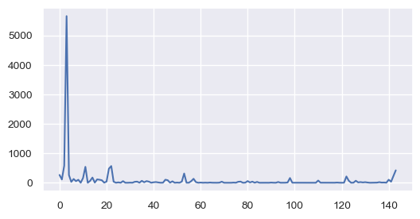

```python
fig = plt.figure(figsize = (6, 3))
sns.set(font_scale=0.9)
plt.plot(f_regression(X_ridge_rfe, y)[0])
plt.show()
```

```python
df_perc_ridge = pd.DataFrame(columns = ["p"] + LISTE_COL )

for p in range(0, 101) :

    selector_ri = SelectPercentile(f_regression, p)
    X_ridge_perc = selector_ri.fit_transform(X_ridge_rfe, y)
    df_perc_ridge = df_perc_ridge.append(dict({"p" : p}, **modelize(Ridge(), "Ridge", X_ridge_perc, y)), ignore_index = True)
```

```python
df_perc_ridge.sort_values("RMSLE")[:5]
```

|  | p | Model | Fit_Time | Score_time | MAE | RMSLE | R2 |
| --- | --- | --- | --- | --- | --- | --- | --- |
| 83 | 83 | Ridge | 0.024001 | 0.005000 | 0.326890 | 0.031411 | 0.822415 |
| 84 | 84 | Ridge | 0.027001 | 0.006001 | 0.327144 | 0.031420 | 0.822337 |
| 77 | 77 | Ridge | 0.027002 | 0.007000 | 0.326345 | 0.031431 | 0.822165 |
| 75 | 75 | Ridge | 0.025001 | 0.005001 | 0.326373 | 0.031432 | 0.822150 |
| 74 | 74 | Ridge | 0.021001 | 0.008000 | 0.326301 | 0.031434 | 0.822120 |

La meilleure configuration est celle ne gardant que les **83%** meilleures variables selon le test **f_regression**.

```python
X_ridge_perc = SelectPercentile(f_regression, 83).fit_transform(X_ridge_rfe, y)
```

```python
X_ridge_perc.shape
```

```
(3303, 119)
```

Cette procédure nous aura permis une légère amélioration des résultats et une réduction dimensionnelle de 144 à 119 variables, doit une diminution de **25** colonnes.

### **SVR**

```python
f_regression(X_svr_rfe, y)
```

```
(array([2.65517529e+02, 1.10992885e+02, 5.79381180e+02, 5.65966636e+03,
        2.61984600e+02, 2.93728877e+01, 1.27410627e+02, 5.42943280e+01,
        1.01249224e+02, 1.32550353e+02, 5.41474587e+02, 1.01211956e-01,
        1.76542640e+02, 1.93935580e+01, 5.65773479e+00, 1.14273764e+02,
        8.47065484e+01, 2.82476567e+00, 4.78387830e+02, 5.66815857e+02,
        3.71573255e+01, 4.70928066e-01, 1.33008472e+01, 7.26289064e+01,
        5.43782528e+01, 2.30427813e-01, 1.30069268e+00, 3.20944085e+01,
        3.77961378e+01, 2.72250885e+00, 6.49260585e+01, 1.61081497e+01,
        5.53883618e+01, 3.80158069e+01, 1.61081497e+01, 1.01000425e+01,
        2.42157497e+00, 1.02850842e+02, 8.64093467e+01, 2.82476567e+00,
        4.83191749e+01, 6.84502174e-01, 3.78477997e+01, 3.14443453e+02,
        1.46494243e+00, 1.95338791e+01, 5.42597104e+01, 1.35262772e+02,
        2.19937003e+01, 7.24384367e+00, 2.36134296e-01, 7.96313043e+00,
        5.03043364e-01, 3.61714276e+01, 5.22665405e-02, 1.61418118e+00,
        4.15428653e-02, 6.20418600e+00, 1.30527399e+00, 3.26346944e+01,
        3.89842579e+01, 5.36417594e-02, 4.04237575e+00, 5.64704455e+01,
        3.80158069e+01, 1.11410285e+00, 2.83268077e+01, 1.07377637e-01,
        8.40016729e-01, 1.30255880e+00, 8.01084560e-01, 3.23292569e-02,
        1.45744620e+00, 2.49920683e+01, 4.98697356e-01, 1.45478961e+00,
        1.79862752e+00, 9.17691797e+00, 1.59044223e+00, 1.48184697e+00,
        4.90675830e-02, 2.52775417e+00, 1.29697001e-02, 1.20044448e+00,
        1.00095204e+00, 2.65317489e+00, 4.30755476e-03, 7.45824513e+01,
        2.20083169e+00, 2.15139534e+00, 9.69316912e-02, 2.68044131e+00,
        1.93571372e+00, 6.99196927e+00, 1.62768328e+00, 2.77085984e-02,
        3.69310725e-01, 2.87268787e+01, 1.47112522e+00, 1.25804091e+01,
        9.53573604e+00, 8.31755101e-01, 2.09213269e+00, 1.19451576e+00,
        2.34760432e+00, 3.56805494e+00, 2.13623121e+02, 4.17412096e+01,
        2.52709536e-01, 2.84213732e+00, 6.79592858e+01, 6.77780899e-01,
        6.17305164e-01, 5.85773813e+00, 1.14108225e+01, 2.34864090e-01,
        2.60207846e+00, 2.22928693e+01, 1.10801639e+01, 1.39235074e+00,
        6.63098246e-01, 1.94540665e+01, 8.18550276e+00, 5.44972389e-02,
        7.00783898e-01, 1.81164910e-04, 4.87700341e+00, 1.99007636e+01,
        6.46497055e+00, 8.61857259e+00, 2.53358212e+00, 1.02859005e+02,
        3.53551653e+01, 2.25759739e+02, 4.22197202e+02]),
 array([1.77892417e-057, 1.50368150e-025, 4.38582639e-118, 0.00000000e+000,
        9.18826436e-057, 6.39932834e-008, 5.10391614e-029, 2.17000945e-013,
        1.76212380e-023, 4.22642103e-030, 4.91223252e-111, 7.50400183e-001,
        2.76444240e-039, 1.09741552e-005, 1.74351202e-002, 3.03542347e-026,
        5.98019719e-020, 9.29150476e-002, 3.80908167e-099, 9.35376003e-116,
        1.21561129e-009, 4.92608721e-001, 2.69383500e-004, 2.34489868e-017,
```

[output cut: 13 more lines]

```
        1.79970777e-001, 2.46984674e-003, 2.07352082e-001, 2.23572786e-001,
        8.24707466e-001, 1.11955082e-001, 9.09336206e-001, 2.73312789e-001,
        3.17153583e-001, 1.03438731e-001, 9.47674814e-001, 8.90592072e-018,
        1.38031766e-001, 1.42535643e-001, 7.55562926e-001, 1.01682890e-001,
        1.64228445e-001, 8.22637871e-003, 2.02113548e-001, 8.67805942e-001,
        5.43422026e-001, 8.90615940e-008, 2.25255032e-001, 3.95233019e-004,
        2.03183951e-003, 3.61832111e-001, 1.48154196e-001, 2.74500315e-001,
        1.25571532e-001, 5.89888489e-002, 6.31295524e-047, 1.19496209e-010,
        6.15207174e-001, 9.19165095e-002, 2.38079673e-016, 4.10411384e-001,
        4.32106860e-001, 1.55623593e-002, 7.38635607e-004, 6.27972555e-001,
        1.06819256e-001, 2.43816882e-006, 8.82132558e-004, 2.38093544e-001,
        4.15527011e-001, 1.06339007e-005, 4.24919811e-003, 8.15429233e-001,
        4.02581018e-001, 9.89261810e-001, 2.72853130e-002, 8.42896795e-006,
        1.10474414e-002, 3.35050421e-003, 1.11542707e-001, 8.01127102e-024,
        3.03409487e-009, 2.08019881e-049, 2.19673375e-088]))
```

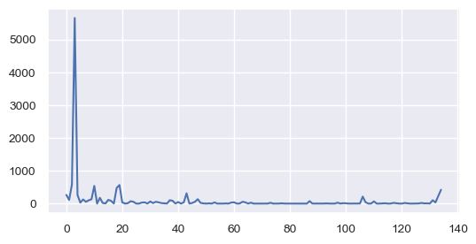

```python
fig = plt.figure(figsize = (6, 3))
sns.set(font_scale=0.9)
plt.plot(f_regression(X_svr_rfe, y)[0])
plt.show()
```

```python
df_perc_svr = pd.DataFrame(columns = ["p"] + LISTE_COL)

for p in range(50, 101) :

    selector_sv = SelectPercentile(f_regression, p)
    X_svr_perc = selector_sv.fit_transform(X_svr_rfe, y)
    df_perc_svr = df_perc_svr.append(dict({"p" : p}, **modelize(SVR(), "SVR", X_svr_perc, y)),
                                     ignore_index = True)
```

```python
df_perc_svr.sort_values("RMSLE")[:5]
```

|  | p | Model | Fit_Time | Score_time | MAE | RMSLE | R2 |
| --- | --- | --- | --- | --- | --- | --- | --- |
| 50 | 100 | SVR | 3.694211 | 0.722041 | 0.312943 | 0.031544 | 0.816318 |
| 49 | 99 | SVR | 3.625207 | 0.711041 | 0.313812 | 0.031600 | 0.815767 |
| 48 | 98 | SVR | 3.632206 | 0.707041 | 0.313828 | 0.031602 | 0.815748 |
| 47 | 97 | SVR | 3.536202 | 0.699040 | 0.313951 | 0.031616 | 0.815578 |
| 43 | 93 | SVR | 3.471199 | 0.674038 | 0.313660 | 0.031639 | 0.815274 |

Pas d'améliorations puisque le meilleur résultat est lorsque qu'on garde **100%** des variables.

```python
X_svr_perc = X_svr_rfe
```

### **Random Forest**

```python
f_regression(X_rf_rfe, y)
```

```
(array([ 265.51752891,  110.99288456,  579.3811798 , 5659.66636099,
         261.98460049,   29.37288766,  127.41062655,   54.29432797,
         101.24922442,  341.55086205,  176.54264   , 2209.00684885,
        1230.01430561,  255.17049415,  331.07486137,  181.73316279,
         225.75973852,  422.19720153,   10.37241879,  617.10591766]),
 array([1.77892417e-057, 1.50368150e-025, 4.38582639e-118, 0.00000000e+000,
        9.18826436e-057, 6.39932834e-008, 5.10391614e-029, 2.17000945e-013,
        1.76212380e-023, 1.20157894e-072, 2.76444240e-039, 0.00000000e+000,
        2.50755248e-229, 2.19116430e-055, 1.41368415e-070, 2.32603755e-040,
        2.08019880e-049, 2.19673375e-088, 1.29153245e-003, 4.95973045e-125]))
```

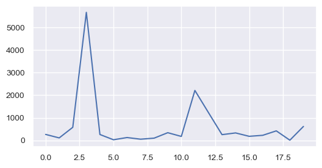

```python
fig = plt.figure(figsize = (6, 3))
sns.set(font_scale=0.9)
plt.plot(f_regression(X_rf_rfe, y)[0])
plt.show()
```

```python
df_perc_rf = pd.DataFrame(columns = ["p"] + LISTE_COL)

for p in range(50, 101) :

    selector_rf = SelectPercentile(f_regression, p)
    X_rf_perc = selector_rf.fit_transform(X_rf_rfe, y)
    df_perc_rf = df_perc_rf.append(dict({"p" : p},
                                        **modelize(RandomForestRegressor(random_state = SEED),
                                                   "Random Forest", X_rf_perc, y)),
                                   ignore_index = True)
```

```python
df_perc_rf.sort_values("RMSLE")[:5]
```

|  | p | Model | Fit_Time | Score_time | MAE | RMSLE | R2 |
| --- | --- | --- | --- | --- | --- | --- | --- |
| 50 | 100 | Random Forest | 5.614321 | 0.089005 | 0.320850 | 0.031403 | 0.820721 |
| 48 | 98 | Random Forest | 5.565318 | 0.087005 | 0.320231 | 0.031422 | 0.820571 |
| 47 | 97 | Random Forest | 5.488315 | 0.091005 | 0.320231 | 0.031422 | 0.820571 |
| 46 | 96 | Random Forest | 5.429311 | 0.087005 | 0.320231 | 0.031422 | 0.820571 |
| 45 | 95 | Random Forest | 5.408309 | 0.087005 | 0.320231 | 0.031422 | 0.820571 |

Là encore, aucune amélioration, ce qui est moins étonnant étant donné la quantité moindre de variables ici.

```python
X_rf_perc = X_rf_rfe
```

### **Gradient Boosting**

```python
f_regression(X_gb_rfe, y)
```

```
(array([ 265.51752891,  110.99288456,  579.3811798 , 5659.66636099,
         261.98460049,   29.37288766,  127.41062655,   54.29432797,
         101.24922442,  339.54242763,  774.59262591,  642.62956192,
        1230.01430561,  255.92149756,  309.71079499,  181.73316279,
         225.75973852,  422.19720153,  617.10591766]),
 array([1.77892417e-057, 1.50368150e-025, 4.38582639e-118, 0.00000000e+000,
        9.18826436e-057, 6.39932834e-008, 5.10391614e-029, 2.17000945e-013,
        1.76212380e-023, 2.99396414e-072, 2.55364338e-153, 1.08089108e-129,
        2.50755248e-229, 1.54428256e-055, 2.46712764e-066, 2.32603755e-040,
        2.08019880e-049, 2.19673375e-088, 4.95973045e-125]))
```

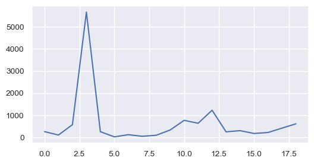

```python
fig = plt.figure(figsize = (6, 3))
sns.set(font_scale=0.9)
plt.plot(f_regression(X_gb_rfe, y)[0])
plt.show()
```

```python
df_perc_gb = pd.DataFrame(columns = ["p"] + LISTE_COL)

for p in range(50, 101) :

    selector_gb = SelectPercentile(f_regression, p)
    X_gb_perc = selector_gb.fit_transform(X_gb_rfe, y)
    df_perc_gb = df_perc_gb.append(dict({"p" : p},
                                        **modelize(GradientBoostingRegressor(random_state = SEED),
                                                   "Gradient BoostingB", X_gb_perc, y)),
                                   ignore_index = True)
```

```python
df_perc_gb.sort_values("R2MSLE")[:5]
```

[output not shown]

Pareil que précédemment, aucun gain de performance.

```python
X_gb_perc = X_gb_rfe
```

Sauvegarde...

```python
liste_X_perc = [X_ridge_perc, X_svr_perc, X_rf_perc, X_gb_perc]
```

```python
pickle_out = open("Data/liste_X_perc.pickle", "wb")
pickle.dump(liste_X_perc, pickle_out)
pickle_out.close()
```

## 12) - Hyper Paramétrage avec **GridSearchCV** et **RandomizedSearchCV**

Il s'agit de l'étape finale de notre modélisation, celle de **l'hyper paramétrage** des modèles.  
Jusqu'à présent, nous n'avons utiliser que des modèles réglés **par défaut** dans notre progression. Maintenant, grâce à **GridSearchCV** et **RandomizedSearchCV** nous allons essayer de trouver les meilleurs réglages possibles de leurs hyper-paramètres.  
Conformement à notre démarche, la métrique qui guidera cette optimisation sera encore la **RMSLE**.

```python
# rechargement des datasets associés aux modèles
liste_X_gs = pickle.load(open("Data/liste_X_perc.pickle", "rb"))

X_ridge_gs = liste_X_gs[0]
X_svr_gs = liste_X_gs[1]
X_rf_gs = liste_X_gs[2]
X_gb_gs = liste_X_gs[3]

# liste des colonnes de nos df de présentations des résultats
LISTE_COL_F = ["Model", "Fit_Time", "Score_time", "MAE", "Std MAE", "RMSLE", "Std RMSLE","R2",
               "Std R2"]

CV = KFold(K, shuffle = True, random_state = SEED)
```

Modification de notre fonction de visualisation afin de tenir compte de l'écart-type des résultats de validation croisée.

```python
def modelize_std(model, name, X, y, k = K) :

    resultats = []

    kf = KFold(k, shuffle = True, random_state = SEED)

    try :
        cv_res = cross_validate(model, X, y, scoring = SCORING, cv = kf)

        resultats.append(name)
        resultats.append(cv_res["fit_time"].sum())
        resultats.append(cv_res["score_time"].sum())
        resultats.append(-cv_res['test_neg_mean_absolute_error'].mean())
        resultats.append(f"\u00B1{np.abs(-cv_res['test_neg_mean_absolute_error'].std()):.4f}")
        resultats.append(np.sqrt(-cv_res['test_neg_mean_squared_log_error']).mean())
        resultats.append(f"\u00B1{np.sqrt(-cv_res['test_neg_mean_squared_log_error']).std():.4f}")
        resultats.append(cv_res['test_r2'].mean())
        resultats.append(f"\u00B1{cv_res['test_r2'].std():.4f}")

    except :

        pass

    new_row = {k:v for k, v in zip(LISTE_COL_F, resultats)}

    return new_row
```

## Optimisation **Ridge**

Dans le cas de l'estimateur **Ridge Régression**, il n'y a qu'un seul hyper-paramètre à optimiser, le coefficient de régularisation **alpha**.

```python
# Grille du paramétrage
param_ridge = {"alpha" : np.logspace(0.001, 1, 50)}

# Définition de la recherche
ridge_grid = GridSearchCV(Ridge(),
                          param_ridge,
                          scoring = "neg_mean_squared_log_error",
                          cv = CV
                         )
```

Lancement de la recherche

```python
start = time()
ridge_grid.fit(X_ridge_gs, y)
print(f"Temps nécessaire à la recherche : {time()-start} secondes.")
```

```
Temps nécessaire à la recherche : 1.7190983295440674 secondes.
```

Nous obtenons le meilleur paramètre **alpha** grâce à l'instruction suivante :

```python
ridge_grid.best_params_
```

```
{'alpha': 1.5292898141606428}
```

Ce qui correspond à ce que nous pouvons observer si nous observons le graph du score en fonction de **alpha** justement...

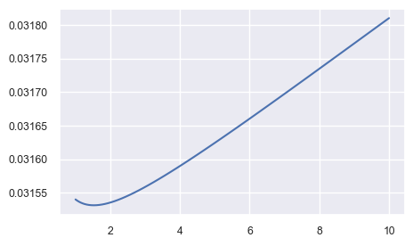

```python
score = np.sqrt(- ridge_grid.cv_results_["mean_test_score"])
fig = plt.figure(figsize = (5, 3))
sns.set(font_scale=0.8)
plt.plot(np.logspace(0.001, 1, 50), score)
plt.show()
```

```python
np.sqrt(-max(ridge_grid.cv_results_["mean_test_score"]))
```

```
0.03153159130312773
```

Nous sommes maintenant en mesure d'obtenir le meilleur estimateur **ridge** de la cible **SiteEnergyUse** avec l'instruction suivante :

```python
b_ridge = ridge_grid.best_estimator_
```

Qui nous donne le résultat suivant :

```python
res_finaux = pd.DataFrame(columns = LISTE_COL_F)

res_finaux = res_finaux.append(modelize_std(b_ridge, "best_ridge", X_ridge_gs, y),
                               ignore_index = True)
res_finaux
```

|  | Model | Fit_Time | Score_time | MAE | Std MAE | RMSLE | Std RMSLE | R2 | Std R2 |
| --- | --- | --- | --- | --- | --- | --- | --- | --- | --- |
| 0 | best_ridge | 0.462027 | 0.010001 | 0.326486 | ±0.0175 | 0.031402 | ±0.0029 | 0.822575 | ±0.0247 |

Sauvegarde

```python
pickle_out = open("Data/b_ridge.pickle", "wb")
pickle.dump(b_ridge, pickle_out)
pickle_out.close()
```

## Optimisation **SVR**

Avec un choix de **kernel** fixé sur **"rbf"** et un choix de **gamma** sur **"scale"**, il va s'agir pour nous ici de trouver de bons réglages sur les hyper-paramètres **C** et **epsilon**.

```python
# Grille de paramétrage
param_SVR = {"kernel" : ["rbf"],
             "gamma" : ["scale"],
             "C" : [0.1, 1, 10, 20, 100, 1000],
             "epsilon" : [0.01, 0.1, 0.5, 1]
            }

# Définition de la recherche
svr_grid = GridSearchCV(SVR(),
                        param_SVR,
                        scoring = "neg_mean_squared_log_error",
                        cv = CV
                       )
```

```python
start = time()
svr_grid.fit(X_svr_gs, y)
print(f"Temps nécessaire à la recherche : {time()-start} secondes.")
```

```
Temps nécessaire à la recherche : 249.01719784736633 secondes.
```

Meilleurs paramètres provisoires :

```python
#svr = svr_grid.best_estimator_
svr_grid.best_params_
```

```
{'C': 1, 'epsilon': 0.1, 'gamma': 'scale', 'kernel': 'rbf'}
```

Seconde recherche plus ciblée

```python
# Grille de paramétrage
param_SVR_2 = {"kernel" : ["rbf"],
             "gamma" : ["scale"],
             "C" : [0.5, 0.75, 1, 1.25, 1.5, 2, 2.5],
             "epsilon" : [0.05, 0.075, 0.1, 0.125, 0.15]
            }

# Définition de la recherche
svr_grid_2 = GridSearchCV(SVR(),
                          param_SVR_2,
                          scoring = "neg_mean_squared_log_error",
                          cv = CV
                          )
```

```python
start = time()
svr_grid_2.fit(X_svr_gs, y)
print(f"Temps nécessaire à la recherche : {time()-start} secondes.")
```

```
Temps nécessaire à la recherche : 162.81328558921814 secondes.
```

Meilleurs hyper-paramètres :

```python
svr_grid_2.best_params_
```

```
{'C': 2.5, 'epsilon': 0.125, 'gamma': 'scale', 'kernel': 'rbf'}
```

Test du meilleur modèle **SVR** :

```python
b_svr = svr_grid_2.best_estimator_
```

```python
res_finaux = res_finaux.append(modelize_std(b_svr, "best_SVR", X_svr_gs, y),
                               ignore_index = True)

res_finaux[res_finaux["Model"]=="best_SVR"]
```

|  | Model | Fit_Time | Score_time | MAE | Std MAE | RMSLE | Std RMSLE | R2 | Std R2 |
| --- | --- | --- | --- | --- | --- | --- | --- | --- | --- |
| 1 | best_SVR | 3.911224 | 0.677038 | 0.310002 | ±0.0187 | 0.031113 | ±0.0033 | 0.822234 | ±0.0270 |

Sauvegarde

```python
pickle_out = open("Data/b_svr.pickle", "wb")
pickle.dump(b_svr, pickle_out)
pickle_out.close()
```

## Optimisation **Random Forest**

En raison du nombre de combinaisons de paramètres à tester, nous allons dans un premier temps effectuer une recherche ramdomisée avec **RandomizedSearchCV** avant, par la suite d'affiner nos résultats avec une utilisation de **GridSearchCV**.

```python
param_RF_rs = {"n_estimators" : [100, 200, 300, 400, 500, 1000, 1500, 2000, 3000],
            "max_depth" : [2, 3, 4, 5, 10, 15, 20],
            "max_features" : ['auto', 'sqrt'],
            "min_samples_split" : [2, 5, 10, 15],
            "min_samples_leaf" : [1, 2, 3, 5, 10]
            }


rf_rand = RandomizedSearchCV(RandomForestRegressor(random_state = SEED),
                             param_RF_rs,
                             n_iter = 200,
                             scoring = "neg_mean_squared_log_error",
                             cv = K)
```

```python
start = time()
rf_rand.fit(X_rf_gs, y)
print(f"Temps nécessaire à la recherche : {time()-start} secondes.")
```

```
Temps nécessaire à la recherche : 3395.126095533371 secondes.
```

```python
rf_rand.best_params_
```

```
{'n_estimators': 300,
 'min_samples_split': 10,
 'min_samples_leaf': 2,
 'max_features': 'auto',
 'max_depth': 15}
```

GridSearch plus localisée

```python
param_RF_gs = {"n_estimators" : [250, 300, 350],
               "max_depth" : [13, 14, 15, 16, 17],
               "max_features" : ['auto'],
               "min_samples_split" : [12, 15, 20, 25],
               "min_samples_leaf" : [2]
              }

rf_grid = GridSearchCV(RandomForestRegressor(random_state = SEED),
                       param_RF_gs,
                       scoring = "neg_mean_squared_log_error",
                       cv = CV
                       )
```

```python
start = time()
rf_grid.fit(X_rf_gs, y)
print(f"Temps nécessaire à la recherche : {time()-start} secondes.")
```

```
Temps nécessaire à la recherche : 675.9426620006561 secondes.
```

Meilleurs paramètres :

```python
rf_grid.best_params_
```

```
{'max_depth': 16,
 'max_features': 'auto',
 'min_samples_leaf': 2,
 'min_samples_split': 12,
 'n_estimators': 350}
```

Modèle RF correspondant

```python
b_rf = rf_grid.best_estimator_
```

```python
res_finaux = res_finaux.append(modelize_std(b_rf, "best_RF", X_rf_gs, y),
                               ignore_index = True)

res_finaux[res_finaux["Model"]=="best_RF"]
```

|  | Model | Fit_Time | Score_time | MAE | Std MAE | RMSLE | Std RMSLE | R2 | Std R2 |
| --- | --- | --- | --- | --- | --- | --- | --- | --- | --- |
| 2 | best_RF | 13.542774 | 0.224013 | 0.32022 | ±0.0143 | 0.031332 | ±0.0030 | 0.821145 | ±0.0258 |

```python
pickle_out = open("Data/b_rf.pickle", "wb")
pickle.dump(b_rf, pickle_out)
pickle_out.close()
```

## Optimisation **Gradient Boosting**

Là encore, le modèle est complexe. Nous allons à nouveau commencer par une recherche randomisée qu'on finalisera avec une grille.  
Les hyper-paramètres que nous allons optimiser sont :

```python
param_gb_rand = {"learning_rate" : [0.05, 0.075, 0.1, 0.125, 0.15],
                 "n_estimators" : [50, 75, 100, 150, 200],
                 "subsample" : [0.8, 0.85, 0.9, 0.95, 1],
                 "max_depth" : [2, 3, 4, 5, 10, 15],
                 "min_samples_split" : [10, 20, 30, 40, 50],
                 "min_samples_leaf" : [5, 10, 20, 30]
                }


gb_rand = RandomizedSearchCV(GradientBoostingRegressor(random_state = SEED),
                             param_gb_rand,
                             n_iter = 400,
                             scoring = "neg_mean_squared_log_error",
                             cv = CV)
```

```python
start = time()
gb_rand.fit(X_gb_gs, y)
print(f"Temps nécessaire à la recherche : {time()-start} secondes.")
```

```
Temps nécessaire à la recherche : 1277.4430632591248 secondes.
```

```python
gb_rand.best_params_
```

```
{'subsample': 0.8,
 'n_estimators': 200,
 'min_samples_split': 20,
 'min_samples_leaf': 10,
 'max_depth': 4,
 'learning_rate': 0.15}
```

GridSearchCV ciblée

```python
param_gb_gs = {"learning_rate" : [0.125, 0.15, 0.175],
               "n_estimators" : [150, 200, 250],
               "subsample" : [0.8],
               "max_depth" : [3, 4, 5],
               "min_samples_split" : [15, 20, 25],
               "min_samples_leaf" : [5, 10, 15]
               }

gb_grid = GridSearchCV(GradientBoostingRegressor(random_state = SEED),
                       param_gb_gs,
                       scoring = "neg_mean_squared_log_error",
                       cv = CV
                      )
```

```python
start = time()
gb_grid.fit(X_gb_gs, y)
print(f"Temps nécessaire à la recherche : {time()-start} secondes.")
```

```
Temps nécessaire à la recherche : 934.5364468097687 secondes.
```

Melleurs paramètres :

```python
gb_grid.best_params_
```

```
{'learning_rate': 0.125,
 'max_depth': 4,
 'min_samples_leaf': 10,
 'min_samples_split': 15,
 'n_estimators': 200,
 'subsample': 0.8}
```

Modèle correspondant :

```python
b_gb = gb_grid.best_estimator_
```

```python
res_finaux = res_finaux.append(modelize_std(b_gb, "best_GB", X_gb_gs, y),
                               ignore_index = True)

res_finaux[res_finaux["Model"]=="best_GB"]
```

|  | Model | Fit_Time | Score_time | MAE | Std MAE | RMSLE | Std RMSLE | R2 | Std R2 |
| --- | --- | --- | --- | --- | --- | --- | --- | --- | --- |
| 3 | best_GB | 3.626207 | 0.017001 | 0.300551 | ±0.0147 | 0.029001 | ±0.0025 | 0.847668 | ±0.0201 |

```python
pickle_out = open("Data/b_gb.pickle", "wb")
pickle.dump(b_gb, pickle_out)
pickle_out.close()
```

Sauvegarde des modèles de la première modélisation

```python
liste_mod_energy = [b_ridge, b_svr, b_rf, b_gb]
```

```python
pickle_out = open("Data/liste_mod_energy.pickle", "wb")
pickle.dump(liste_mod_energy, pickle_out)
pickle_out.close()
```

# 11) - Discussion des résultats

## Choix du modèle

Récapitulation des performances obtenus

```python
res_finaux
```

|  | Model | Fit_Time | Score_time | MAE | Std MAE | RMSLE | Std RMSLE | R2 | Std R2 |
| --- | --- | --- | --- | --- | --- | --- | --- | --- | --- |
| 0 | best_ridge | 0.462027 | 0.010001 | 0.326486 | ±0.0175 | 0.031402 | ±0.0029 | 0.822575 | ±0.0247 |
| 1 | best_SVR | 3.911224 | 0.677038 | 0.310002 | ±0.0187 | 0.031113 | ±0.0033 | 0.822234 | ±0.0270 |
| 2 | best_RF | 13.542774 | 0.224013 | 0.320220 | ±0.0143 | 0.031332 | ±0.0030 | 0.821145 | ±0.0258 |
| 3 | best_GB | 3.626207 | 0.017001 | 0.300551 | ±0.0147 | 0.029001 | ±0.0025 | 0.847668 | ±0.0201 |

Au vu des résultats ci-dessus, et sous réserve de considérations du commenditaire de cette étude, nous considérons que le meilleur modèle à utiliser est celui qui est basé sur l'algotithme **Gradient Boosting**.  
Ses performances sont **notablement supérieures** aux autres tout en n'étant supplanté que par la Régression Ridge en terme de ressources nécessaires à son utilisation.  
Avec quasiment la variance de prédiction la plus faible quelle que soit la métrique qu'on regarde parmi celles que nous avons utilisées, notre modèle **Gradient Boosting** se pose également comme le plus fiable.

## **Livrable du modèle**

Livrable entrainé du modèle de la variable **SiteEnergyUseWN(kBtu)**.

```python
mod_seu_livrable = b_gb.fit(X_gb_gs, y)
```

```python
# Sauvergarde
pickle_out = open("Data/mod1.pickle", "wb")
pickle.dump(mod_seu_livrable, pickle_out)
pickle_out.close()
```

## Modélisation finale sans **outliers**

Au départ de notre travail, nous pensions que la présence d'outliers pourrait nuire à nos résultats.  
Cette hypothèse avait été contredite dès le départ par des résultats de modélisation moins bon sans outliers qu'avec.  
Nous allons néanmoins regarder, en bout de chaîne, si notre modèle final confirme ceci.

Enlevons les rangs de notre dataset, à présent sous forme de **tableau numpy**, les rangs correspondant aux observations qui sont des **outliers**.

```python
mask = np.array(X["Outlier"])

# dataset np.array sans "outliers"
X_gb_no = X_gb_gs[mask == 0,:]
```

Modélisation :

```python
modelize(b_gb, "Modèle final GB sans outliers", X_gb_no, y_no)
```

```
{'Model': 'Modèle final GB sans outliers',
 'Fit_Time': 3.3051886558532715,
 'Score_time': 0.016000986099243164,
 'MAE': 0.30063690647129515,
 'RMSLE': 0.02966092079621078,
 'R2': 0.8112427017408306}
```

Les résultats sont encore une fois moins bons.  
Plus précisément, la **MAE** et la **RMSLE** sans **outliers** sont moins bonnes qu'avec de façon minime, alors que la différence est plus marquée sur le **score R2**.  
En tout état de cause, il s'avère qu'au cours de cette modélisation, les observations que nous considérions comme des **outliers** n'auront pas constitué un problème, au contraire.

## Importance de la variable **EnergyStarScore**

Repenchons-nous également sur l'importance qu'a la variable **EnergyStarScore** pour notre modèle final.

```python
res, mod = modelize(b_gb, "Modèle final GB", X_gb_gs, y, True)
res
```

```
{'Model': 'Modèle final GB',
 'Fit_Time': 3.6202070713043213,
 'Score_time': 0.017000913619995117,
 'MAE': 0.3005506233133254,
 'RMSLE': 0.029001037777681538,
 'R2': 0.8476678096808794}
```

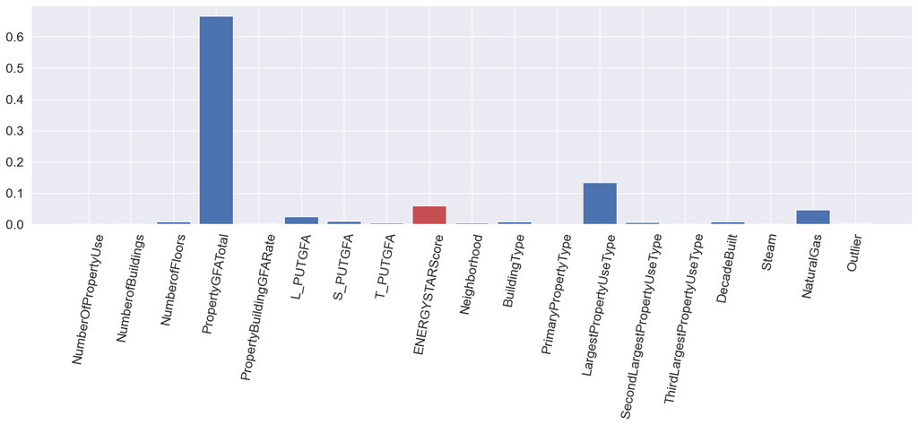

```python
fig = plt.figure(figsize = (20,5))

color = ["b"]*len(mod.feature_importances_)
color[8] = "r"

sns.set(font_scale=1.5)
plt.bar(range(len(mod.feature_importances_)), mod.feature_importances_, color = color)
plt.xticks(np.arange(len(X_gb.columns)), X_gb.columns, rotation = 80)
plt.show()
```

Comme on peut le voirsur le graphe ci-dessus, l'**EnergyStarScore** a une importance notable dans notre modélisation.  
C'est même la **3ème** variable la plus importante.  
Quantification de cette importance (en %) :

```python
f"{mod.feature_importances_[8]*100} %"
```

```
'5.96449043872063 %'
```

Modélisation sans la variable **EnergyStarScore**

```python
X_gb_ness = np.delete(X_gb_gs, 8, 1)
```

```python
modelize(b_gb, "Modèle final GB", X_gb_ness, y)
```

```
{'Model': 'Modèle final GB',
 'Fit_Time': 3.315190076828003,
 'Score_time': 0.01800060272216797,
 'MAE': 0.36451604520546643,
 'RMSLE': 0.03400017689555217,
 'R2': 0.7912940371458281}
```

Comme attendu, les résultats sont nettement moins bon.  
Au regard des différents résultats que nous avons obtenus, nous sommes en mesure d'affirmer que l'**EnergyStarScore**, tel que nous en avons imputées les valeurs manquantes dès le départ par sa valeur médiane, est une variable qui contribue positivement et significativement à notre modèle. Cette contribution étant évaluée à environ **6%**.  
La question nous a été posée parce que l'**EnergyStarScore** est une donnée dont l'acquisition est difficile et onéreuse et il ne nous appartient pas de répondre directement à la question de savoir s'il faut continuer ou pas le calcul de cet indicateur. Nous affirmons juste qu'en l'état, s'en passer diminue grandement la qualité de modélisation, plus de **5 points au score R2**.  
Par contre, il est peut-être quand même possible d'obtenir une qualité de modélisation équivalente sans utiliser l'**EnergyStarScore**...

## Analyse des **Learning Curves**

Nous allons observer l'influence de la quantité de données d'entrainement sur la qualité de deux modèles, un tenant compte de l'**EnergyStarScore**, l'autre non.

```python
lc_gb = learning_curve(b_gb, X_gb_gs, y ,train_sizes = np.linspace(0.05, 1, 20),
                       scoring = "r2",
                       cv = KFold(K, shuffle = True, random_state = SEED))
lc_gb_ness = learning_curve(b_gb, X_gb_ness, y ,train_sizes = np.linspace(0.05, 1, 20),
                            scoring = "r2",
                            cv = KFold(K, shuffle = True, random_state = SEED))
```

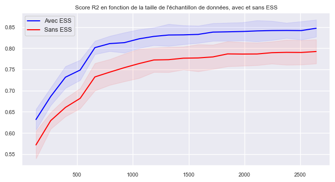

```python
test_scores = lc_gb[2].mean(axis = 1)
test_scores_std = lc_gb[2].std(axis = 1)
test_scores_ness = lc_gb_ness[2].mean(axis = 1)
test_scores_ness_std = lc_gb_ness[2].std(axis = 1)

fig = plt.figure(figsize = (8, 4))

plt.plot(lc_gb[0], test_scores, color='blue', label="Avec ESS")

plt.fill_between(lc_gb[0],
                 test_scores - test_scores_std,
                 test_scores + test_scores_std, alpha=0.08,
                 color="blue")

plt.plot(lc_gb_ness[0], test_scores_ness, color='red', label="Sans ESS")

plt.fill_between(lc_gb[0],
                 test_scores_ness - test_scores_ness_std,
                 test_scores_ness + test_scores_ness_std, alpha=0.08,
                 color="red")
plt.title("Score R2 en fonction de la taille de l'échantillon de données, avec et sans ESS")

sns.set(font_scale = 0.8)
plt.legend()
plt.show()
```

Ce graph nous montre que nos modélisations devraient pouvoir s'améliorer si on travaillaient sur plus de données.  
Avec pour corollaire que même si le modèle **avec EnergyStarScore** sera probablement toujours meilleur, multiplier la taille de l'échantillon de données pourrait compenser sa non utilisation, sous réserve naturellement que la trajectoire des courbes se maintienne et que la quantité de données supplémentaire soit massive étant donnée la pente des courbes.

## Facteurs possibles d'erreur

Nous allons adjoindre à notre dataset une variable **erreur**, qui sera la valeur absolue de l'erreur mesurée par notre modèle pour chaque observation. Afin d'accéder à chaque prédiction nous allons utiliser la fonction **cross_val_predict**.

```python
# récupération des données, modèle et dataset

liste_mod_energy = pickle.load(open("Data/liste_mod_energy.pickle", "rb"))
b_gb = liste_mod_energy[3]

liste_X_gs = pickle.load(open("Data/liste_X_perc.pickle", "rb"))
X_gb_gs = liste_X_gs[3]
```

```python
pred = cross_val_predict(b_gb, X_gb_gs, y,
                         cv = KFold(K, shuffle = True, random_state = SEED))
```

```python
erreur = np.abs(pred - y)

X_gb_an = X_gb.copy()
X_gb_an["erreur"] = erreur
X_gb_an.head(3)
```

[output not shown]

En utilisant le module **dython** nous allons regarder si apparaissent des corrélations avec notre nouvelle variable d'erreurs...

```python
categ = ['Neighborhood', 'BuildingType', 'PrimaryPropertyType',
       'LargestPropertyUseType', 'SecondLargestPropertyUseType',
       'ThirdLargestPropertyUseType', 'DecadeBuilt']

for col in categ :
    X_gb_an[col] = X_gb_an[col].astype("str")
```

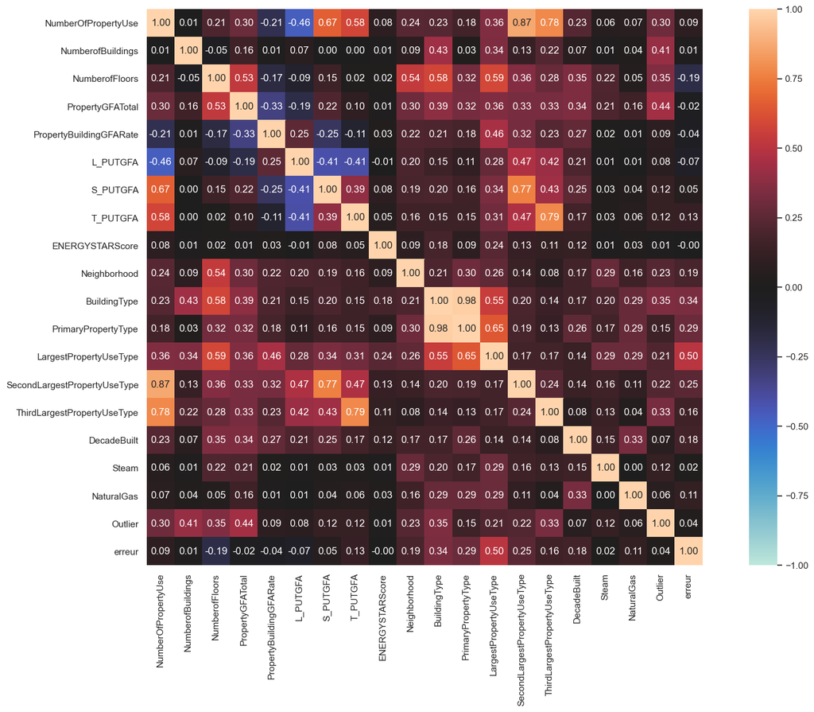

```python
associations(
    X_gb_an,
    figsize = (20,12),
    nominal_columns = "auto",
    theil_u = False,
    cbar = True,
    annot = True,
    fmt = ".2f"
)
plt.show()
```

Les variables les plus corrélées avec l'erreur de prédiction sont certaines de nos variables catégorielles. Nous allons observer la relation entre les catégories de la variable **LargestPropertyUseType** et l'erreur moyenne de notre prédiction (classée par ordre décroissant).

```python
liste_val = X_gb_an['LargestPropertyUseType'].value_counts().index

liste_mean = []

for val in liste_val :
    X_val = X_gb_an[X_gb_an['LargestPropertyUseType'] == val]
    liste_mean.append(X_gb_an[X_gb_an['LargestPropertyUseType'] == val]["erreur"].mean())

serie = pd.Series(liste_val, liste_mean).sort_index(ascending = False)
```

[figure not shown]

```python
fig = plt.figure(figsize = (10, 20))
sns.set(font_scale = 1.1)
plt.title(f"Erreur en fonction de la catégorie 'LargestPropertyUseType'")
sns.boxplot(X_gb_an["erreur"], X_gb_an['LargestPropertyUseType'], showmeans = True, order = serie)
plt.show()
```

Ce graph nous nous montre que les catégories de bâtiments, qui correspondent à des besoins et à des consommations d'énergie très différents, mais qui correspondant aussi à des fréquences de présence différentes dans le dataset, sont un important facteur d'erreur.

Maintenant nous allons regarder quels types de bâtiments contribuent cumulativement le plus à l'erreur.

```python
erreur_tot = X_gb_an['erreur'].sum()
```

```python
liste_er_sum = []

for val in liste_val :
    X_val = X_gb_an[X_gb_an['LargestPropertyUseType'] == val]
    liste_er_sum.append(X_gb_an[X_gb_an['LargestPropertyUseType'] == val]["erreur"].sum())

serie_er_sum = pd.Series(liste_val, liste_er_sum).sort_index(ascending = False)
```

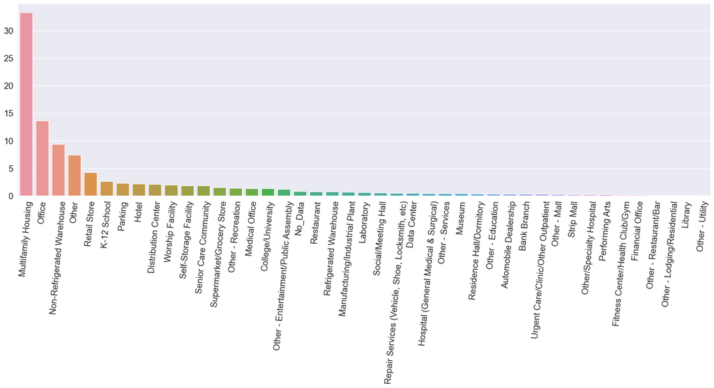

```python
fig = plt.figure(figsize = (25, 7))
sns.set(font_scale = 1.6)
sns.barplot(serie_er_sum.values, (serie_er_sum.index/erreur_tot)*100)
plt.xticks(rotation=80)
plt.xticks(np.arange(len(liste_val)), serie_er_sum.values, rotation = 85)

plt.show()
```

On pourrait diminuer cette erreur, et l'erreur globale du modèle, en compartimentant la modélisation par type de bâtiments ou regroupements de types de bâtiments. Débarassées de nombreux "bruits", des modélisations plus parcellaires seraient probablement meilleures.  
Meilleures mais aussi incomplètes puisqu'elle ne tiendrait pas compte de nombreux types de bâtiments.  
Une solution qui pourrait permettre d'améliorer une modélisation globale comme celle que nous avons faite serait d'augmenter l'échelle de l'étude, en passant de l'échelle d'une ville à celle d'une région ou d'un état. Avec plus de données, les modèles seraient plus en mesure de modéliser de manière satisfaisante tous ces bâtiments "rares" aux caractéristiques et consommations différentes. Cependant, cela pourrait nécessiter un travail colossal nécessitant une énorme coordination en ce qui concerne la collecte et la mise en un format commun des données.  
Une autre solution à envisager pourrait résider dans l'utilisation de modèles de type **réseaux de neurones**, qui pourraient peut-être s'avérer plus adaptés à nos données. Il s'agirait d'une solution intermédiaire qui nécéssiterait pour être vraiment efficace que nous ayons accès à plus de données qu'en l'état.

## Que donne le modèle dans la **vraie vie** ?

Les différentes transformations opérées sur nos données, et particulièrement notre cible, ont pu **déconnecter** nos résultats d'une interprétation *dans la vraie vie* accessible à tous.  
Après tout, au départ il s'agissait de prévoir une consommation énergétique tout ce qu'il y a de plus concrête, mais nous avons choisi de prévoir une transformation logarithmique de cette consommation, en nous guidant de surcroît avec des métriques pouvant également paraître abstraites à beaucoup de gens.  
Pour savoir ce que notre modèle donne comme résultat dans le format original de nos données, il suffit de reprendre nos prédictions et de les transformer par la **fonction exponentielle**.

```python
pred_real = np.exp(pred)
```

Ensuite on peut reprendre notre dataset initial, y accoler les valeurs cibles, les prévisions, l'erreur, le pourcentage d'erreur, et même une répartition par **tranche** de ces pourcentages...

```python
X_results = pickle.load(open("Data/X.pickle", "rb"))
y_results = pickle.load(open("Data/y.pickle", "rb"))
```

```python
X_results["conso_cible"] = y_results["SiteEnergyUseWN(kBtu)"]
X_results["prédictions"] = pred_real
X_results["erreur"] = np.abs(X_results["prédictions"] - X_results["conso_cible"])
X_results["% d'erreur"] = X_results["erreur"] / X_results["conso_cible"] * 100
X_results["% tranche"] = (X_results["% d'erreur"] // 10)
```

```python
X_results[['LargestPropertyUseType',"conso_cible", "prédictions", "erreur",
           "% d'erreur", "% tranche"]].head(5)
```

|  | LargestPropertyUseType | conso_cible | prédictions | erreur | % d'erreur | % tranche |
| --- | --- | --- | --- | --- | --- | --- |
| 0 | Multifamily Housing | 3379678.0 | 2.239475e+06 | 1.140203e+06 | 33.737024 | 3.0 |
| 1 | Multifamily Housing | 1369895.0 | 1.237408e+06 | 1.324873e+05 | 9.671349 | 0.0 |
| 2 | Retail Store | 10155788.0 | 2.262881e+06 | 7.892907e+06 | 77.718312 | 7.0 |
| 3 | Office | 6541579.0 | 7.085177e+06 | 5.435976e+05 | 8.309884 | 0.0 |
| 4 | Office | 16463978.0 | 1.097355e+07 | 5.490426e+06 | 33.348114 | 3.0 |

On peut en profiter pour regarder toute sorte de chose, comme par exemple les bâtiments pour lesquels, en % d'erreur, notre modèle s'est le plus trompé.

```python
X_results[['LargestPropertyUseType',"conso_cible", "prédictions", "erreur",
           "% d'erreur", "% tranche"]].sort_values("% tranche", ascending = False).head(5)
```

|  | LargestPropertyUseType | conso_cible | prédictions | erreur | % d'erreur | % tranche |
| --- | --- | --- | --- | --- | --- | --- |
| 2233 | Other | 17260.00000 | 8.150748e+05 | 7.978148e+05 | 4622.333538 | 462.0 |
| 1277 | Office | 24105.50000 | 9.099961e+05 | 8.858906e+05 | 3675.056100 | 367.0 |
| 1343 | Other | 44293.50000 | 8.237363e+05 | 7.794428e+05 | 1759.722649 | 175.0 |
| 3195 | Other | 72370.39844 | 1.291867e+06 | 1.219496e+06 | 1685.076017 | 168.0 |
| 1051 | Supermarket/Grocery Store | 267135.09380 | 3.038143e+06 | 2.771008e+06 | 1037.305877 | 103.0 |

Et là de voir que notre modèle peut avoir de **1680 %** à **4620 %** d'erreur sur des bâtiments à très petite consommation...

Ensuite, afin d'avoir une vue concrête et globale, on peut afficher l'histogramme de cette dernière variable, après avoir toutefois regroupé tous ces **outliers** en une variable.

```python
X_results.loc[X_results["% tranche"] > 10, "% tranche"] = 11
```

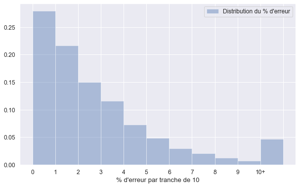

```python
fig = plt.figure(figsize = (10,6))
sns.set(font_scale=1.1)
ax = sns.distplot(X_results["% tranche"],
                  bins = 11,
                  kde = False,
                  axlabel = "% d'erreur par tranche de 10",
                  label = "Distribution du % d'erreur",
                  norm_hist = True)
ax.set_xticks(range(12))
ax.set_xticklabels(['0','1','2','3','4','5','6','7', '8', '9', '10+', ''])
plt.legend()
plt.show()
```

Notre modèle a manifestement encore une grande marge d'amélioration...  
Passons au second dans le notebook suivant...

**FIN de la première partie**